# Análisis datos cáncer de mama

Abril García Luque, Ana León Miranda, Ana Liqing Sánchez Castellano

2024-12-16

[figure not shown]

## Introducción

El cáncer de mama es una enfermedad en la que las células del tejido mamario crecen de **manera descontrolada**, formando un tumor maligno. Es el tipo de cáncer más común en mujeres. Su detección temprana, mediante *autoexploraciones,* *mamografías* y *chequeos médicos*, mejora significativamente las posibilidades de tratamiento exitoso.

## Objetivos

El objetivo de este proyecto es ver qué tipo de cirugía es más exitosa y la edad media en la que se detecta este tumor maligno.

## Materiales y métodos

Las librerías que vamos a necesitar son:

```
library('dplyr')
library('ggplot2')
```

Además, los datos que vamos a utilizar para hacer nuestro análisis se encuentran en [kaggle](https://www.kaggle.com/datasets/raghadalharbi/breast-cancer-gene-expression-profiles-metabric/data).

## Análisis de los datos

En primer lugar asignamos los datos a una variable.

```
mydata <- read.csv("METABRIC_RNA_Mutation.csv")
```

Lo primero que queremos observar es sobre qué edad se diagnostican más casos de cáncer de mama.

[figure not shown]

**Figura** **1:** Diagrama de densidad edad.

```
mydata %>% ggplot(aes(x = age_at_diagnosis)) +
  geom_density() +
  ggtitle("Gráfico edad") +
  labs(x = "Edad")
```

Hacemos un análisis estadístico que muestre la **media**, el **máximo** y el **mínimo** de la edad de las personas que sufren este tipo de cáncer.

```
mydata %>% summarise(total_casos = n(),
                     media = mean(age_at_diagnosis),
                     maximo = max(age_at_diagnosis),
                     minimo = min(age_at_diagnosis))
```

```
##   total_casos    media maximo minimo
## 1        1904 61.08705  96.29  21.93
```

Primero veremos cuántos pacientes han sobrevivido al haberse sometido a una mastectomía, para ello seleccionaremos las columnas que queremos comparar.

[output not shown]

```r
mydata %>% select(type_of_breast_surgery, overall_survival) %>%
  head()
```

```
##   type_of_breast_surgery overall_survival
## 1             MASTECTOMY                1
## 2      BREAST CONSERVING                1
## 3             MASTECTOMY                0
## 4             MASTECTOMY                1
## 5             MASTECTOMY                0
## 6             MASTECTOMY                0
```

Después, asignaremos una variable con los datos seleccionados.

```r
datos_selected <- mydata %>% select(type_of_breast_surgery, overall_survival)
```

Ahora, filtraremos los datos para obtener solo los casos de los pacientes que se hayan sometido a la **mastectomía** y asignamos una variable.

```r
datos_selected %>% filter(type_of_breast_surgery == "MASTECTOMY") %>% head()
```

```
##   type_of_breast_surgery overall_survival
## 1             MASTECTOMY                1
## 2             MASTECTOMY                0
## 3             MASTECTOMY                1
## 4             MASTECTOMY                0
## 5             MASTECTOMY                0
## 6             MASTECTOMY                0
```

```r
mastectomia <- datos_selected %>% filter(type_of_breast_surgery == "MASTECTOMY")
```

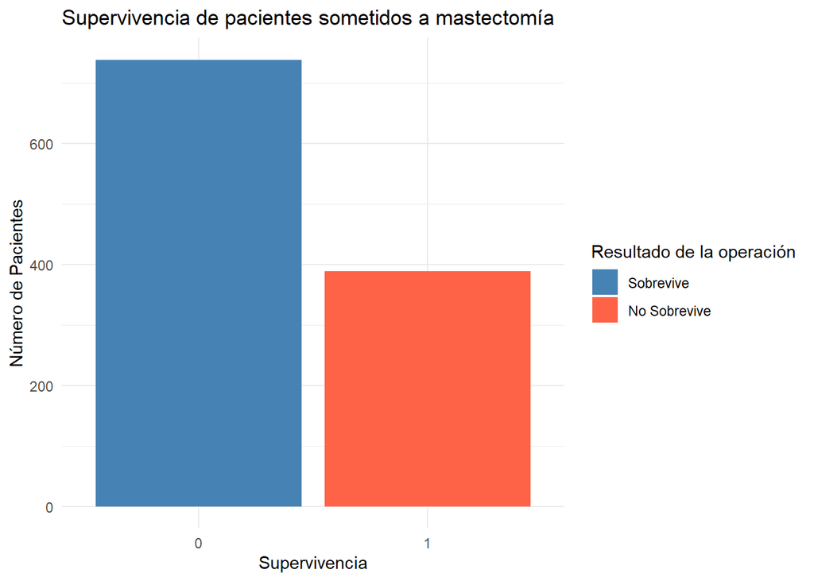

**Figura** **2:** Supervivencia pacientes sometidos a mastectomía. 0=sobreviven, 1=no sobreviven.

```r
mastectomia %>%
  ggplot(aes(x = factor(overall_survival), fill = factor(overall_survival))) +
  geom_bar() +
  scale_fill_manual(values = c("steelblue", "tomato"),
                    labels = c("Sobrevive", "No Sobrevive")) +
  labs(
    x = "Supervivencia",
    y = "Número de Pacientes",
    title = "Supervivencia de pacientes sometidos a mastectomía",
    fill = "Resultado de la operación"
  ) +
  theme_minimal()
```

Una vez obtenido el gráfico, analizamos el número de pacientes que sobreviven y aquellos que no.  
**SOBREVIVEN:**

```r
mastectomia %>% filter(type_of_breast_surgery == "MASTECTOMY") %>%
  filter(overall_survival == 0) %>% nrow()
```

```
## [1] 738
```

**NO SOBREVIVEN:**

```r
mastectomia %>% filter(type_of_breast_surgery == "MASTECTOMY") %>%
  filter(overall_survival == 1) %>% nrow()
```

```
## [1] 389
```

Hacemos lo mismo, pero con *Breast conserving*. Para ver cuántos pacientes han sobrevivido al haberse sometido a una operación en la que **sí conservan** parte del tejido mamario seleccionaremos las columnas que queremos comparar.  
Asignamos la variable *conservan* a los datos ya filtrados.

```r
datos_selected %>% filter(type_of_breast_surgery == "BREAST CONSERVING") %>% head()
```

```
##   type_of_breast_surgery overall_survival
## 1      BREAST CONSERVING                1
## 2      BREAST CONSERVING                1
## 3      BREAST CONSERVING                0
## 4      BREAST CONSERVING                0
## 5      BREAST CONSERVING                1
## 6      BREAST CONSERVING                1
```

```r
conservan <- datos_selected %>% filter(type_of_breast_surgery == "BREAST CONSERVING")
```

Realizamos en gráfico para comparar la supervivencia entre los pacientes.

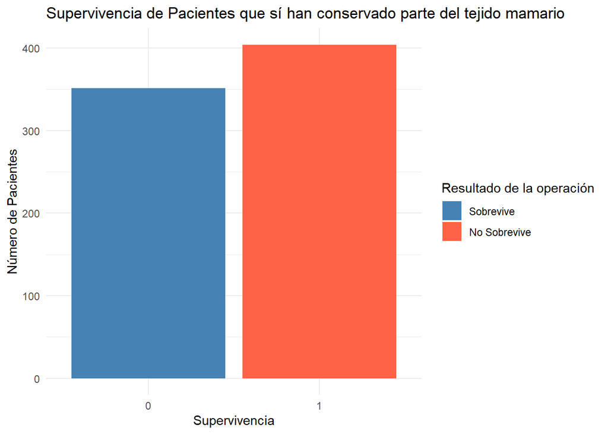

**Figura** **3:** Supervivencia pacientes que conservan su tejido mamario. 0=sobreviven, 1=no sobreviven.

```r
conservan %>%
  ggplot(aes(x = factor(overall_survival), fill = factor(overall_survival))) +
  geom_bar() +
  scale_fill_manual(values = c("steelblue", "tomato"),
                    labels = c("Sobrevive", "No Sobrevive")) +
  labs(
    x = "Supervivencia",
    y = "Número de Pacientes",
    title = "Supervivencia de Pacientes que sí han conservado parte del tejido mamario ",
    fill = "Resultado de la operación"
  ) +
  theme_minimal()
```

Para saber el número de pacientes que sobreviven y aquellos que no.

**SOBREVIVEN:**

```r
conservan %>% filter(type_of_breast_surgery == "BREAST CONSERVING") %>%
  filter(overall_survival == 0) %>% nrow()
```

```
## [1] 351
```

**NO SOBREVIVEN:**

```r
conservan %>% filter(type_of_breast_surgery == "BREAST CONSERVING") %>%
  filter(overall_survival == 1) %>% nrow()
```

```
## [1] 404
```

## Conclusión

En base al análisis estadístico, podemos concluir que la población que más sufre este tipo de cáncer son las mujeres cuya edad oscila entre los 61 años. Aunque en nuestra base de datos el rango en el que es posible encontrar pacientes que padezcan este tipo de enfermedad oscila desde los 22 hasta los 96 años.

Finalmente podemos concluir que el método de cirugía con mayor éxito de supervivencia es la mastectomía, siendo la supervivencia en mastectomía 738 y la supervivencia de la cirugía donde se conserva el tejido mamario 351.

## Información de la sesión

R version 4.3.1 (2023-06-16 ucrt) Platform: x86_64-w64-mingw32/x64 (64-bit) Running under: Windows 10 x64 (build 19045)

Matrix products: default

locale: [1] LC_COLLATE=Spanish_Spain.utf8 LC_CTYPE=Spanish_Spain.utf8  
[3] LC_MONETARY=Spanish_Spain.utf8 LC_NUMERIC=C  
[5] LC_TIME=Spanish_Spain.utf8

time zone: Europe/Madrid tzcode source: internal

attached base packages: [1] stats graphics grDevices utils datasets methods  
[7] base

loaded via a namespace (and not attached): [1] compiler_4.3.1 fastmap_1.2.0 cli_3.6.1  
[4] htmltools_0.5.8.1 tools_4.3.1 yaml_2.3.10  
[7] rmarkdown_2.29 grid_4.3.1 knitr_1.49  
[10] xfun_0.49 digest_0.6.33 rlang_1.1.1  
[13] evaluate_0.22

## Bibliografía

R Core Team. 2024. *R: A Language and Environment for Statistical Computing*. Vienna, Austria: R Foundation for Statistical Computing. https://www.R-project.org/.

Wickham, Hadley, Winston Chang, Lionel Henry, Thomas Lin Pedersen, Kohske Takahashi, Claus Wilke, Kara Woo, Hiroaki Yutani, Dewey Dunnington, and Teun van den Brand. 2024. *Ggplot2: Create Elegant Data Visualisations Using the Grammar of Graphics*. https://ggplot2.tidyverse.org.

Wickham, Hadley, Romain François, Lionel Henry, Kirill Müller, and Davis Vaughan. 2023. *Dplyr: A Grammar of Data Manipulation*. https://dplyr.tidyverse.org.